# (점프) 데이터 스터디

fueleconomy QUIZ

2025-02-25

## Spring Quiz

```r
pacman::p_load(fueleconomy)                # data set
library(tidyverse)                         # tidyverse

# install.packages('devtools')             # devtools
# devtools::install_github('bbc/bbplot').   # bbc/bbplot
library(bbplot)                            # bbplot

library(showtext)                          # showtext
showtext_auto()                            # showtext_auto()


vehicles |> head()
vehicles |> glimpse()
vehicles |>
  mutate_at(vars(make, model, class, trans, drive, fuel), factor) |>
  str()
vehicles |>
  is.na() |>
  colSums() |>
  as_tibble(rownames = 'NA')
```

### 1. geom_point()

> x = displ, y = cty, goem_point 그래프를 그리시오  
> displ의 NA값은 제외하시오 (57개)  
> - drop_na(), geom_point(alpha = .3)

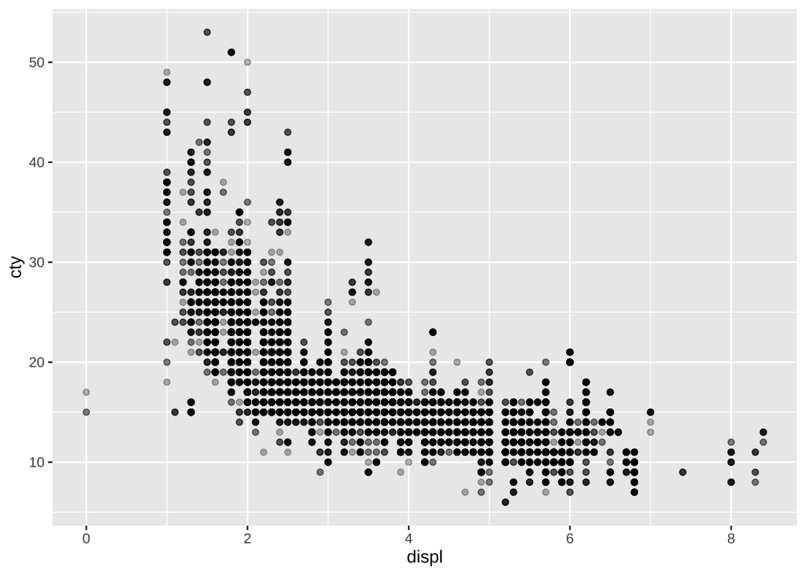

### 2. group_by(), reframe()

> 제조사별 평균 고속도로 연비를 계산하시오  
> 고속도로 연비는 소수 첫째자리에서 반올림하시오 - group_by(), reframe(), mean(), hwy

```
## # A tibble: 128 × 2
##    make            avg_hwy
##    <chr>             <dbl>
##  1 Tesla              93.3
##  2 CODA Automotive    68
##  3 BYD                64.7
##  4 Azure Dynamics     62
##  5 smart              54.3
##  6 Fiat               44
##  7 MINI               33.3
##  8 Daihatsu           32.5
##  9 Scion              32.0
## 10 Red Shift Ltd.     31
## # ℹ 118 more rows
```

### 3. na.rm = T

> 2015년 차량들의 평균 엔진크기(displ)를 계산하시오  
> - filter(), reframe(), year, displ

```
## # A tibble: 1 × 1
##   avg_cty
##     <dbl>
## 1      NA
```

### 4. count(), arrange(), desc()

> 모델수가 가장 많은 제조사 3개의 모델수는 각각 몇개인지 계산하시오  
> - count(), arrange(), head(), desc(), make

```
## # A tibble: 3 × 2
##   make          n
##   <chr>     <int>
## 1 Chevrolet  3461
## 2 Ford       2807
## 3 Dodge      2350
```

### 5. filter(%in%)

> 2010년 이후 Tesla와 Toyota가 생산한 차량을 연도별로 계산하시오  
> - filter(), count(), make, year,

```
## # A tibble: 8 × 3
## # Groups:   year [5]
##    year make       n
##   <dbl> <chr>  <int>
## 1  2010 Toyota    57
## 2  2011 Toyota    59
## 3  2012 Tesla      1
## 4  2012 Toyota    59
## 5  2013 Tesla      3
## 6  2013 Toyota    59
## 7  2014 Tesla      2
## 8  2014 Toyota    58
```

### 6. pivot_wider() —- 어려움

> 2010년부터 2013년까지 전기차량의 drive와 class를 계산해 넓은 형식으로 출력하시오  
> - filter(), count(), pivot_wider(name_from = drive, value_from = n)  
> - Electricity, year, class, drive

```
## # A tibble: 10 × 3
##    class                           `Front-Wheel Drive` `Rear-Wheel Drive`
##    <chr>                                         <int>              <int>
##  1 Compact Cars                                      2                 NA
##  2 Midsize Cars                                      3                 NA
##  3 Minicompact Cars                                  2                 NA
##  4 Small Sport Utility Vehicle 2WD                   2                 NA
##  5 Small Station Wagons                              1                 NA
##  6 Special Purpose Vehicle 2WD                       2                 NA
##  7 Sport Utility Vehicle - 2WD                       2                 NA
##  8 Subcompact Cars                                   2                  3
##  9 Large Cars                                       NA                  4
## 10 Two Seaters                                      NA                  4
```

### 7.geom_bar(), geom_label()

> Hyundai의 자동차 생산 대수를 연도별 막대그래프로 시각화하시오  
> 기간 : 2001년~ 2014년  
> - group_by(), reframe(), year, make, n(), goem_bar(), geom_label()

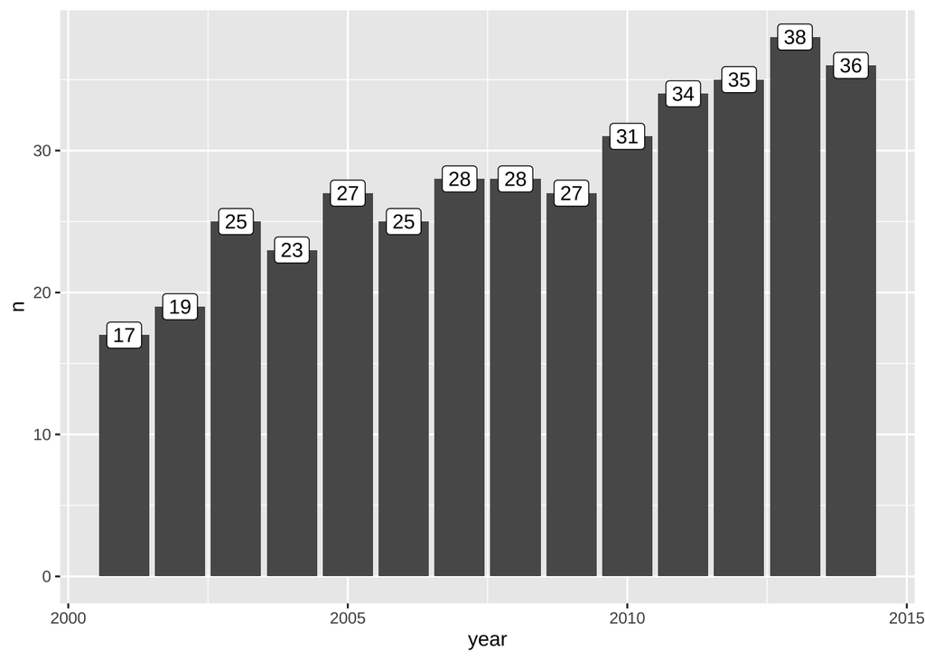

### 8. bbc_style(), coord_flip() — 어려움

> ‘메르세데스-벤츠’(Mercedes-Benz) 차량 중 도시연비가 가장 좋은 모델 5개를 시각화하시오  
> 내림차순으로 정렬하시오  
> - make, year, cty, drive, fuel, model  
> - bbc_style(), ggtitle()  
> - geom_bar(), geom_label(), mean(), fct_reorder(), head(), coord_flip()

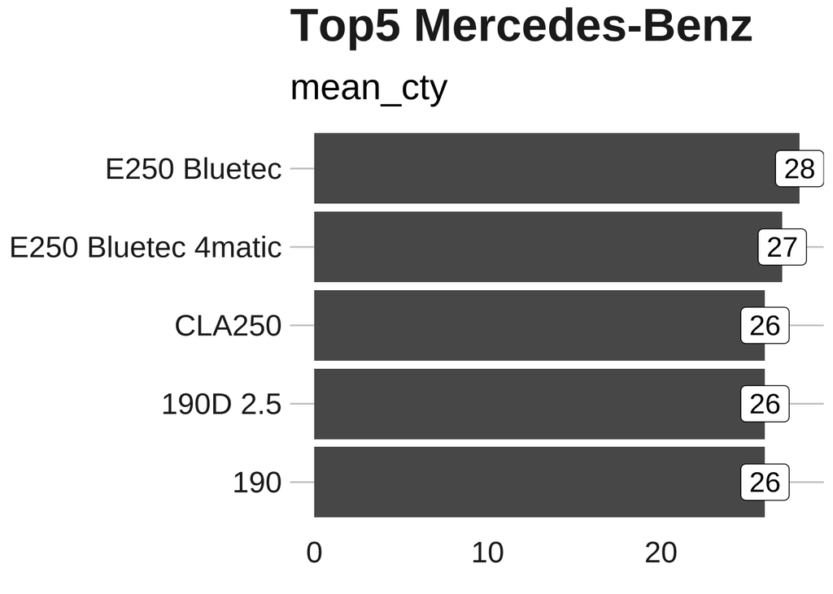

### 9. top_n(), arrange(), slice_max(with_ties = F)

> 연료를 기준으로 자동차 수를 상위 10개만 출력하시오  
> - top 10 안에 동점이 있을 경우 모두 포함하시오  
> - fuel, count()

```
## # A tibble: 11 × 2
##    fuel                            n
##    <chr>                       <int>
##  1 Regular                     22622
##  2 Premium                      8617
##  3 Gasoline or E85              1043
##  4 Diesel                        874
##  5 Premium or E85                 88
##  6 CNG                            58
##  7 Electricity                    55
##  8 Midgrade                       43
##  9 Gasoline or natural gas        18
## 10 Gasoline or propane             8
## 11 Regular Gas and Electricity     8
```

### 10. NA 조회

> trans의 종류는 총 몇개인가?  
> - 힌트 없음

```
## # A tibble: 47 × 2
##    trans                                n
##    <chr>                            <int>
##  1 Automatic 4-spd                  10771
##  2 Manual 5-spd                      7858
##  3 Automatic 3-spd                   2720
##  4 Automatic 5-spd                   2158
##  5 Manual 6-spd                      2067
##  6 Automatic (S6)                    1946
##  7 Manual 4-spd                      1368
##  8 Automatic 6-spd                   1135
##  9 Automatic (S5)                     816
## 10 Automatic (variable gear ratios)   554
## # ℹ 37 more rows
```

### 11. NA 조회 (중요)

> 모든 컬럼에 NA 여부를 계산하고 tibble 형태로 출력하시오  
> - is.na(), colSums(), as_tibble()

```
## # A tibble: 12 × 2
##    `NA`  value
##    <chr> <dbl>
##  1 id        0
##  2 make      0
##  3 model     0
##  4 year      0
##  5 class     0
##  6 trans     8
##  7 drive     0
##  8 cyl      58
##  9 displ    57
## 10 fuel      0
## 11 hwy       0
## 12 cty       0
```

### 12. mean() 함정1

> 2010년부터 2015년까지 평균 도시연비가 높은 제조사 Top 5를 시각화하라  
> - geom_bar(), filter(), group_by(), reframe(), top_n(), geom_label()

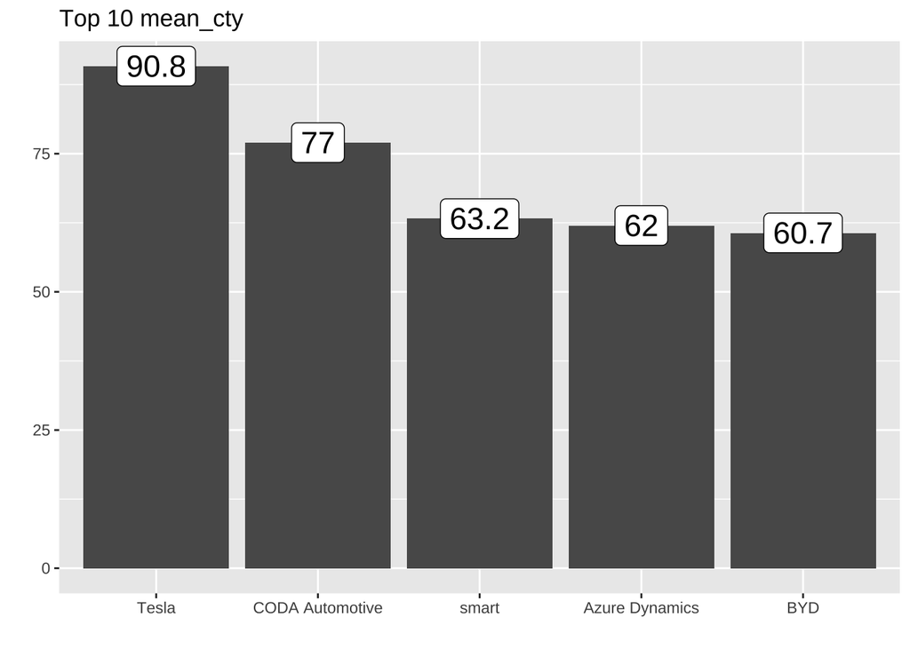

### 13. mean() 함정2

> 2010년부터 2015년까지 생산 모델수가 5개 이상인 제조사 중 평균 도시연비가 높은 제조사 Top 5를 시각화하라  
> 12번 그래프와 비교하라  
> - geom_bar(),xlab(), ylab(), top_n(), geom_label(), n()

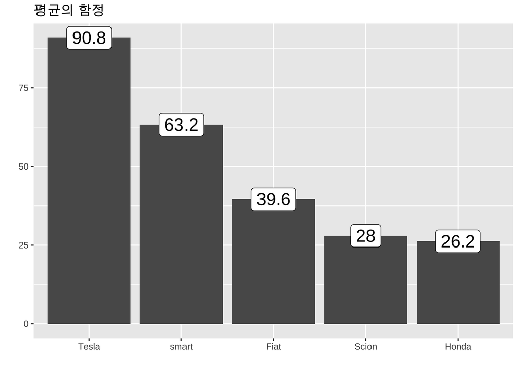

### 14. geom_jitter()

> 4기통 자동차와 8기통 자동차의 도시 연비와 고속도로 연비를 시각화 하시오  
> geom_jitter(), filter(), factor(cyl)  
> - cty, hwy, alpha = .3, ggtitle()

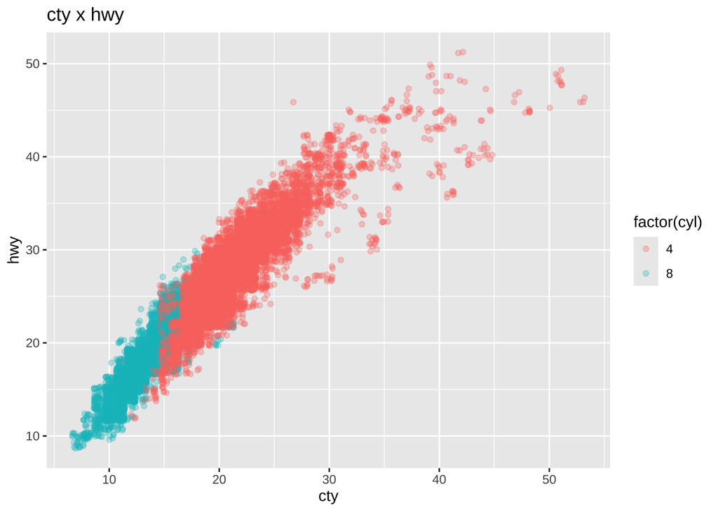

### 15. fecet_wrap()면분할

> 위 그래프를 drive 별로 면분할 하시오  
> geom_jitter(), filter(), factor(cyl)  
> - cty, hwy, alpha = .3, ggtitle(), facet_wrap()

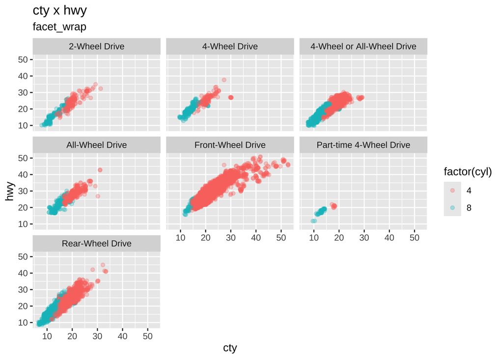

### 16. 요약통계

> cyl(실린더) 크기를 기준으로 displ(배기량)의 요약통계를 계산하시오  
> - group_by(), reframe(), mean(), median(), sd(), min(), max()

```
## # A tibble: 10 × 6
##      cyl mean_displ median_displ sd_displ min_displ max_displ
##    <dbl>      <dbl>        <dbl>    <dbl>     <dbl>     <dbl>
##  1     2       1.28          1.3   0.0576       1.1       1.3
##  2     3       1.04          1     0.0881       1         1.5
##  3     4       2.07          2     0.343        1         3.5
##  4     5       2.64          2.5   0.491        2.1       3.7
##  5     6       3.45          3.4   0.568        1.8       5.3
##  6     8       5.23          5.2   0.672        0         7.4
##  7    10       5.92          5.2   1.32         4.8       8.4
##  8    12       5.84          5.9   0.453        4.7       6.7
##  9    16       8             8     0            8         8
## 10    NA       1.3           1.3  NA            1.3       1.3
```

### 17. x축 레이블 회전

> 2014년 기준 제조사별 평균 배기량(displ)을 막대 그래프로 시각화하시오  
> na 제거  
> - group_by(), reframe(), geom_bar()를 사용하시오  
> - theme(axis.text.x = element_text(angle = 90, hjust = 1))

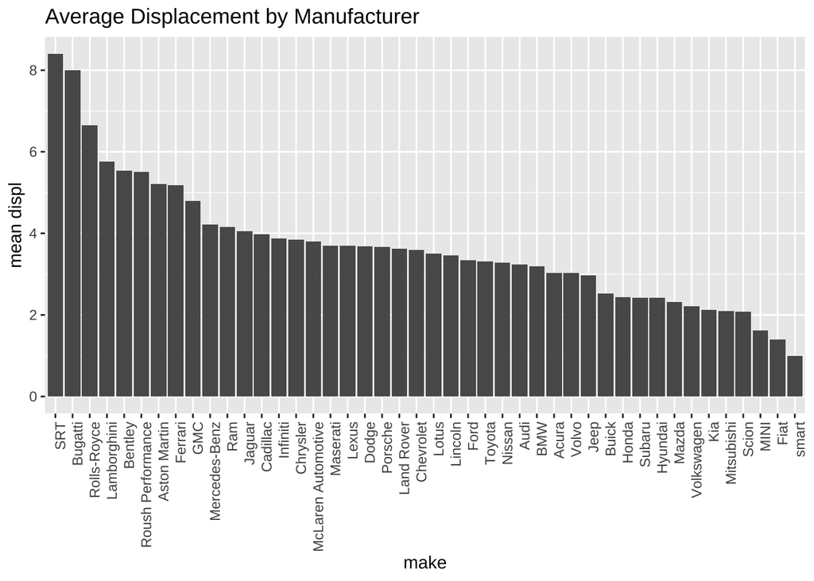

### 18. geom_tile(), xlab()

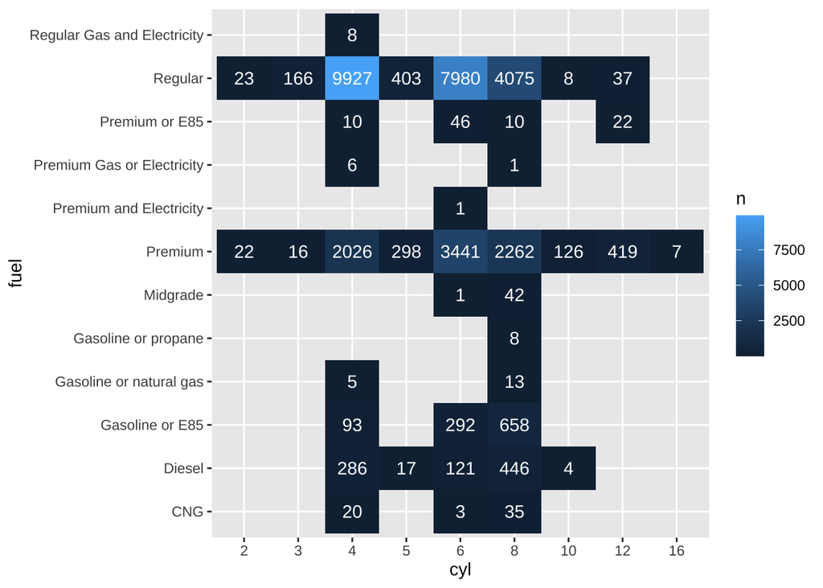

### 19. theme_minimal(), theme()

> 18번에서 만든 그래프에 theme_minimal을 적용하시오 theme() 함수를 사용해 심미성을 높이시오

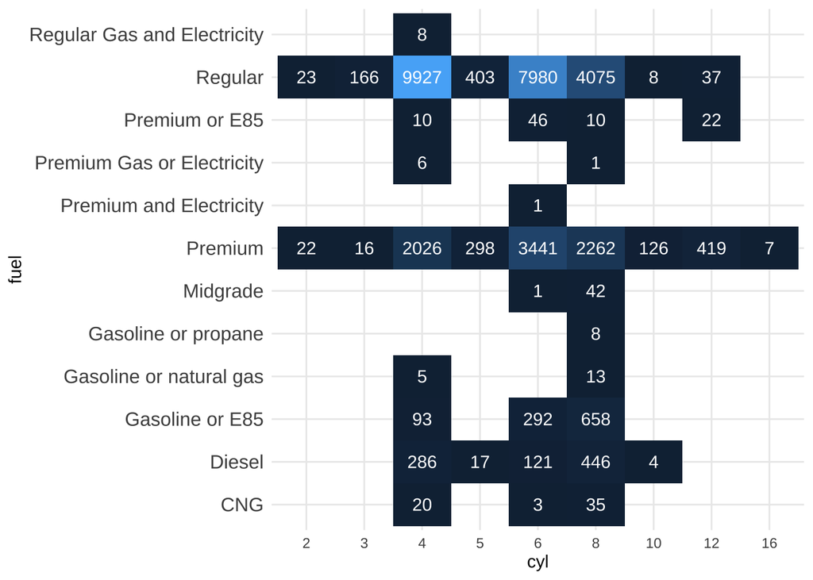

### 20. boxplot()

> 연료 유형별 고속도로 연비 분포를 상자 그림으로 시각화하시오  
> geom_jitter(width = .1, alpha = .1)을 덧붙이세요 - x = fuel, y = hwy, ggplot(), geom_boxplot()

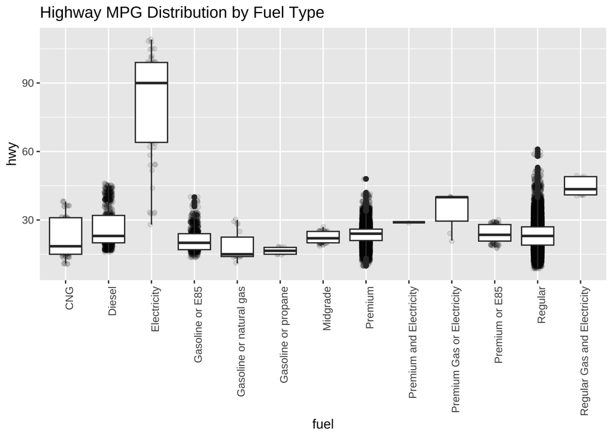

### 21. mutate(), slice()

> (A)고속도로 연비보다 도시연비가 좋은 차 5대를 출력하시오 (B) 도시연비보다 고속도로 연비가 좋은 차 5대를 출력하시오 A와 B를 한 화면에 출력하시오 - mutate(), arrange(), slice()

```
## # A tibble: 10 × 13
##      gap    id make  model  year class trans drive   cyl displ fuel    hwy   cty
##    <dbl> <dbl> <chr> <chr> <dbl> <chr> <chr> <chr> <dbl> <dbl> <chr> <dbl> <dbl>
##  1   -33 33307 Scion iQ EV  2013 Mini… Auto… Fron…    NA  NA   Elec…   105   138
##  2   -29 33305 smart fort…  2013 Two … Auto… Rear…    NA  NA   Elec…    93   122
##  3   -29 34393 smart fort…  2014 Two … Auto… Rear…    NA  NA   Elec…    93   122
##  4   -29 33306 smart fort…  2013 Two … Auto… Rear…    NA  NA   Elec…    93   122
##  5   -29 34394 smart fort…  2014 Two … Auto… Rear…    NA  NA   Elec…    93   122
##  6    14 31377 Chev… Cruz…  2012 Mids… Manu… Fron…     4   1.4 Regu…    42    28
##  7    14 32542 Chev… Cruz…  2013 Mids… Manu… Fron…     4   1.4 Regu…    42    28
##  8    14 34079 Chev… Cruz…  2014 Mids… Manu… Fron…     4   1.4 Regu…    42    28
##  9    14 34396 Merc… E250…  2014 Mids… Auto… Rear…     4   2.1 Dies…    42    28
## 10    19 33578 Chev… Cruze  2014 Mids… Auto… Fron…     4   2   Dies…    46    27
```

### 22. geom_histogram()

> 고속도로 연비의 분포를 히스토그램으로 그리시오 - geom_histogram(), binwidth = 3

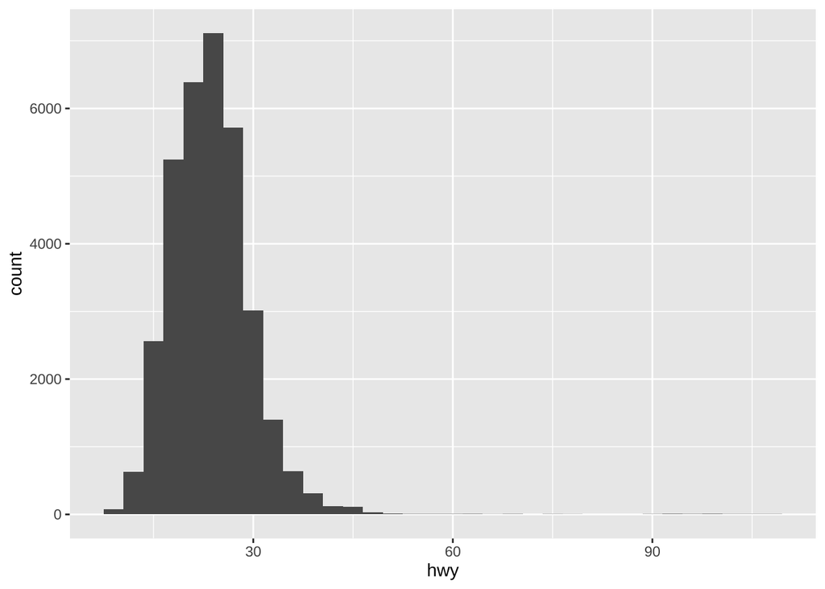

### 23. 선형 회귀

> 도시 연비와 고속도로 연비를 선형회귀로 시각화 하시오. - geom_smooth(), geom_point()

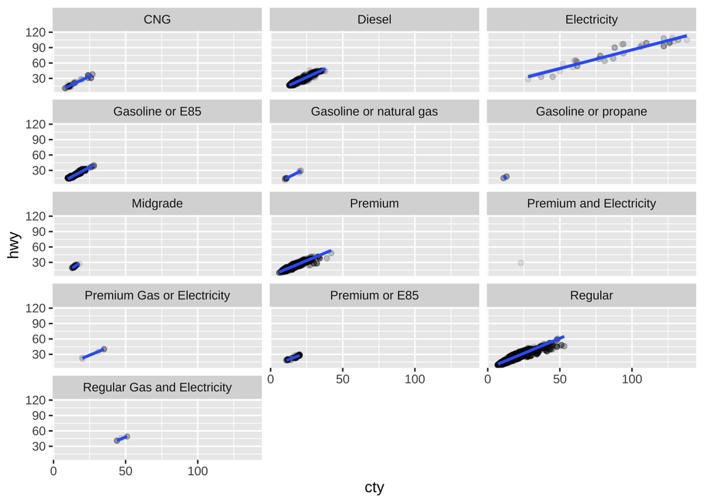